# main

### 2. PCA

1. Apply PCA to the data.
2. Decide the number of principal components.
3. Use the PCA function to calculate the final result.

```r
# Apply PCA to data
pc.res = prcomp(numerical.data, scale = TRUE)
pc.res
```

```
## Standard deviations (1, .., p=19):
##  [1] 2.5056262 1.4313175 1.2199726 1.0173632 1.0017871 0.9953857 0.9267711
##  [8] 0.8626686 0.8373858 0.7954436 0.7558573 0.6690398 0.6560464 0.6493515
## [15] 0.6229615 0.5724593 0.4914755 0.4763238 0.4039521
##
## Rotation (n x k) = (19 x 19):
##                              PC1          PC2           PC3         PC4
## Education            0.014907551 -0.154468107 -0.3536098270 -0.58495606
## Marital_Status      -0.009250346 -0.036038272 -0.0490782900 -0.19584607
## Income               0.341504364 -0.038790398 -0.1867424856 -0.05356526
## Kidhome             -0.267711861  0.045034653  0.1735724744 -0.10176916
## Teenhome            -0.043835456 -0.501359981 -0.2549653768  0.26156284
## Dt_Customer         -0.034671692  0.221289920 -0.4936058630  0.10913556
## Recency              0.006504481 -0.007124473  0.0282196078  0.56496049
## MntWines             0.302445460 -0.187461110 -0.0080775769 -0.18533091
## MntFruits            0.279626040  0.138299413  0.1482951206  0.07962695
## MntMeatProducts      0.320763166  0.130610237  0.0467935163 -0.10046407
## MntFishProducts      0.289270281  0.146205450  0.1409700701  0.07893542
## MntSweetProducts     0.280088093  0.118827459  0.1408144143  0.08806603
## MntGoldProds         0.230449708 -0.099361632  0.2333187717  0.16544304
## NumDealsPurchases   -0.048816327 -0.486486552  0.2404264891 -0.02675369
## NumWebPurchases      0.222476553 -0.364856875  0.1516402429 -0.06668524
## NumCatalogPurchases  0.326791135 -0.007163995  0.0001787418 -0.06664773
## NumStorePurchases    0.299933324 -0.162947577 -0.0125444210 -0.06291256
## NumWebVisitsMonth   -0.259156802 -0.254357305  0.3519575821 -0.08992255
## Age                  0.068199044 -0.305187603 -0.4181918076  0.30487862
##                              PC5         PC6         PC7          PC8
## Education            0.009787301 -0.43721550  0.04963854 -0.305972004
## Marital_Status       0.893939858  0.34992392 -0.18112233  0.007594024
## Income               0.028168930 -0.04338897  0.10359038  0.042767574
## Kidhome              0.106844292 -0.05386804  0.41252277 -0.291103971
## Teenhome            -0.012857688  0.17950811  0.10103415 -0.092133336
## Dt_Customer          0.025258143  0.20460382  0.60149976  0.267940287
## Recency              0.408772235 -0.69792510  0.07123330  0.051288985
## MntWines             0.003821313 -0.16419579 -0.07556999  0.286068842
## MntFruits           -0.009077402  0.12836897  0.09847068 -0.312053594
## MntMeatProducts      0.042264868 -0.11852025  0.05338867 -0.096509810
## MntFishProducts      0.006083782  0.10776229  0.04705999 -0.329850527
## MntSweetProducts     0.030233090  0.08126186  0.08590524 -0.323695749
## MntGoldProds        -0.044537926  0.13837341  0.01898090  0.173981288
```

[output cut: 51 more lines]

```
## Teenhome             0.117410402  0.182776681 -0.164765409
## Dt_Customer          0.077900135  0.043801200  0.015539685
## Recency              0.001099076 -0.004702898  0.016863508
## MntWines            -0.182944358 -0.386019925 -0.335815068
## MntFruits           -0.119173910 -0.035516309 -0.013086968
## MntMeatProducts      0.747592322  0.072182564 -0.244429004
## MntFishProducts     -0.057768259 -0.074455064 -0.002390768
## MntSweetProducts    -0.002893706 -0.014580066 -0.034302474
## MntGoldProds         0.128047726 -0.016332309  0.013689502
## NumDealsPurchases   -0.061813767 -0.340440187  0.031725150
## NumWebPurchases     -0.069506653  0.089892956 -0.163848853
## NumCatalogPurchases -0.486848416  0.579007196  0.076935698
## NumStorePurchases    0.174719947  0.414654447  0.071410770
## NumWebVisitsMonth    0.265720903  0.233028125  0.427631908
## Age                  0.018940440  0.004634491  0.006036118
```

```r
# we pick 9 components to explain 80% of variance
cumsum(pc.res$sdev^2/sum(pc.res$sdev^2))
```

```
##  [1] 0.3304296 0.4382543 0.5165877 0.5710628 0.6238827 0.6760297 0.7212352
##  [8] 0.7604034 0.7973095 0.8306111 0.8606806 0.8842392 0.9068917 0.9290842
## [15] 0.9495095 0.9667574 0.9794704 0.9914117 1.0000000
```

```r
pc.loading = data.frame(pc.res$rotation[1:19,1:9])
pc.loading
```

|  | PC1 | PC2 | PC3 | PC4 | PC5 | PC6 | PC7 | PC8 | PC9 |
| --- | --- | --- | --- | --- | --- | --- | --- | --- | --- |
| Education | 0.014907551 | -0.154468107 | -0.3536098270 | -0.58495606 | 0.009787301 | -0.43721550 | 0.04963854 | -0.305972004 | 0.41405284 |
| Marital_Status | -0.009250346 | -0.036038272 | -0.0490782900 | -0.19584607 | 0.893939858 | 0.34992392 | -0.18112233 | 0.007594024 | 0.03016495 |
| Income | 0.341504364 | -0.038790398 | -0.1867424856 | -0.05356526 | 0.028168930 | -0.04338897 | 0.10359038 | 0.042767574 | -0.17351304 |
| Kidhome | -0.267711861 | 0.045034653 | 0.1735724744 | -0.10176916 | 0.106844292 | -0.05386804 | 0.41252277 | -0.291103971 | -0.11886745 |
| Teenhome | -0.043835456 | -0.501359981 | -0.2549653768 | 0.26156284 | -0.012857688 | 0.17950811 | 0.10103415 | -0.092133336 | -0.01830600 |
| Dt_Customer | -0.034671692 | 0.221289920 | -0.4936058630 | 0.10913556 | 0.025258143 | 0.20460382 | 0.60149976 | 0.267940287 | 0.18638839 |
| Recency | 0.006504481 | -0.007124473 | 0.0282196078 | 0.56496049 | 0.408772235 | -0.69792510 | 0.07123330 | 0.051288985 | 0.11420264 |
| MntWines | 0.302445460 | -0.187461110 | -0.0080775769 | -0.18533091 | 0.003821313 | -0.16419579 | -0.07556999 | 0.286068842 | -0.13248598 |
| MntFruits | 0.279626040 | 0.138299413 | 0.1482951206 | 0.07962695 | -0.009077402 | 0.12836897 | 0.09847068 | -0.312053594 | 0.23244444 |
| MntMeatProducts | 0.320763166 | 0.130610237 | 0.0467935163 | -0.10046407 | 0.042264868 | -0.11852025 | 0.05338867 | -0.096509810 | -0.37511313 |

[output cut: 9 more lines]

```r
# prepare data for heat map
pc.loading$features = rownames(pc.loading)
pr.loading.df = melt(pc.loading)
pr.loading.df$features = factor(pr.loading.df$features, levels = c("Education", "Marital_Status", "Kidhome", "Teenhome", "Age",
                                                           "Dt_Customer", "Income", "Recency", "MntWines", "MntFruits",
                                                           "MntMeatProducts", "MntFishProducts", "MntSweetProducts",
                                                           "MntGoldProds", "NumDealsPurchases", "NumWebPurchases",
                                                           "NumCatalogPurchases", "NumStorePurchases", "NumWebVisitsMonth"))
```

### 3. ICA

1. Apply ICA to the data.
2. Use the ICA function to calculate the final result.

```r
# We select 6 since it can capture variables features very well
set.seed(20)
ica = fastICA(numerical.data, 6, fun = "logcosh", alpha = 1,
                   row.norm = T, maxit = 200,
                   tol = 0.0001, verbose = FALSE)
ica.latent =  ica$S
```

```r
ica.loading = data.frame(t(ica$A)) %>%
  rename_with(~ str_glue("IC{seq(.)}")) %>%
  mutate(variable = names(numerical.data)) %>%
  pivot_longer(cols = starts_with("IC"), names_to = "components", values_to = "loading")

# prepare data for heat map
colnames(ica.loading) = c("features","variable","value")
ica.loading$features = factor(ica.loading$features, levels = c("Education", "Marital_Status", "Kidhome", "Teenhome", "Age",
                                                              "Dt_Customer", "Income", "Recency", "MntWines", "MntFruits",
                                                              "MntMeatProducts", "MntFishProducts", "MntSweetProducts",
                                                              "MntGoldProds", "NumDealsPurchases", "NumWebPurchases",
                                                              "NumCatalogPurchases", "NumStorePurchases", "NumWebVisitsMonth"))
```

### 4. Compare the components of three methods

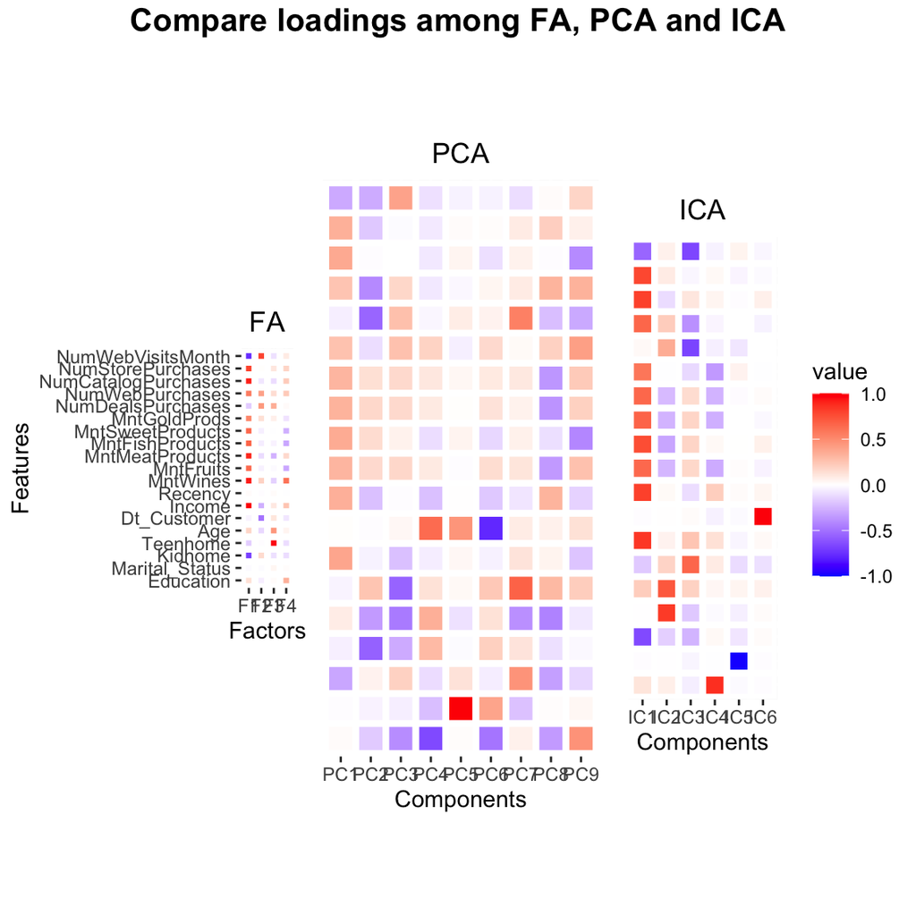

```r
fa.plot = ggplot(fa.df, aes(x = variable, y = factor(features, level = features.order), fill = value)) +
  geom_tile(color = "white",
            lwd = 1.5,
            linetype = 1, show.legend = FALSE) +
  scale_fill_gradient2(low='blue',high='red') +
  ylab("Features") + xlab("Factors") + ggtitle('FA') +
  coord_fixed() + theme(plot.title = element_text(hjust = 0.5))

pr.plot = ggplot(pr.loading.df, aes(x = variable, y = factor(features, level = features.order), fill = value)) +
  geom_tile(color = "white",
            lwd = 1.5,
            linetype = 1, show.legend = FALSE) +
  scale_fill_gradient2(low='blue',high='red') + xlab("Components") + ggtitle('PCA') +
  coord_fixed() + ylab(NULL) +
  theme(axis.text.y=element_blank(), axis.ticks.y=element_blank(), plot.title = element_text(hjust = 0.5))

ica.plot = ggplot(ica.loading, aes(x = variable, y = factor(features, level = features.order), fill = value)) +
  geom_tile(color = "white", lwd = 1.5, linetype = 1) +
  scale_fill_gradient2(low='blue',high='red',limits=c(-1,1)) + xlab("Components") + ggtitle('ICA') +
  coord_fixed() + ylab(NULL) +
  theme(axis.text.y=element_blank(), axis.ticks.y=element_blank(), plot.title = element_text(hjust = 0.5))

# heat map comparison plot
grid.arrange(fa.plot, pr.plot, ica.plot, nrow = 1,
             top=textGrob("Compare loadings among FA, PCA and ICA", gp=gpar(fontsize=15, font = 2)))
```

## IV. Clustering

We are going to use KMeans clustering to cluster the data after applying ICA. 1. Select the number of clusters based on the elbow plot. 2. Apply KMeans clustering to the data.

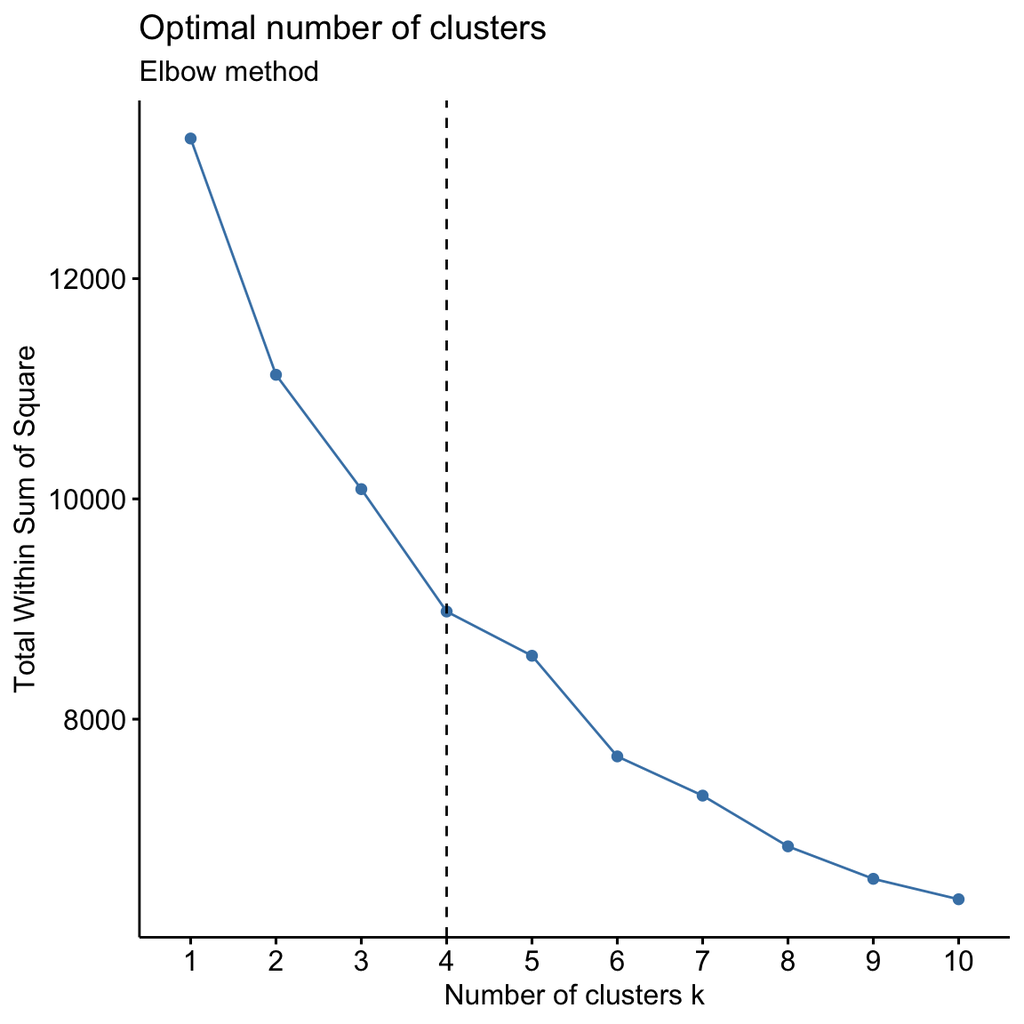

```r
# elbow plot
fviz_nbclust(ica.latent, kmeans, method = "wss") +
  geom_vline(xintercept = 4, linetype = 2) + # add line for better visualisation
  labs(subtitle = "Elbow method") # add subtitle
```

We decide to use 4 clusters.

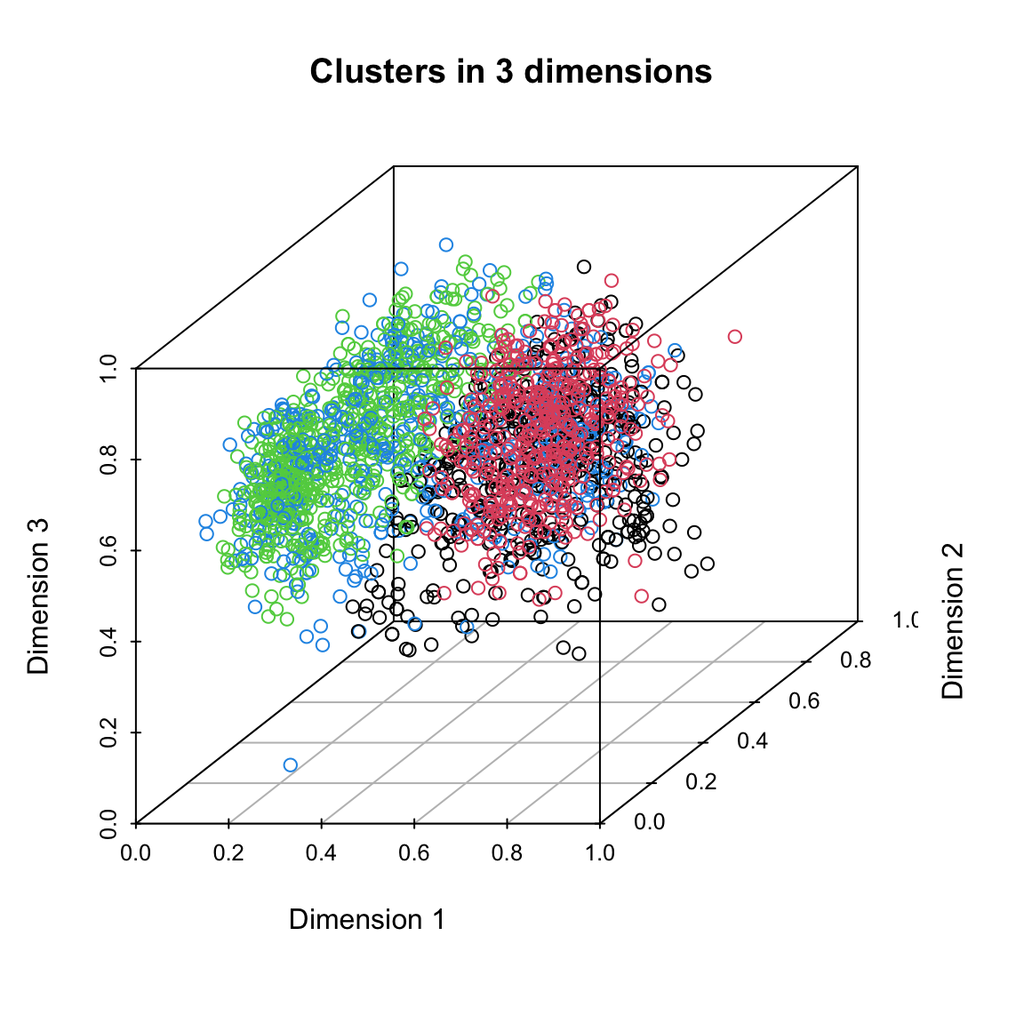

```r
kmean.model.4 = kmeans(ica.latent, 4, nstart = 10)
kmean.model.4.cluster = kmean.model.4$cluster
# Have a brief look at the cluster
# define a function to do min max scale
min.max.scale <- function(x){(x-min(x))/(max(x)-min(x))}
scatterplot3d(min.max.scale(ica.latent[,1]),min.max.scale(ica.latent[,2]),min.max.scale(ica.latent[,3]),color = kmean.model.4.cluster, main='Clusters in 3 dimensions',xlab ='Dimension 1',ylab= 'Dimension 2', zlab= 'Dimension 3',scale.y = 1)
```

## V. Access the model

We are going to use RFM model to access the model.

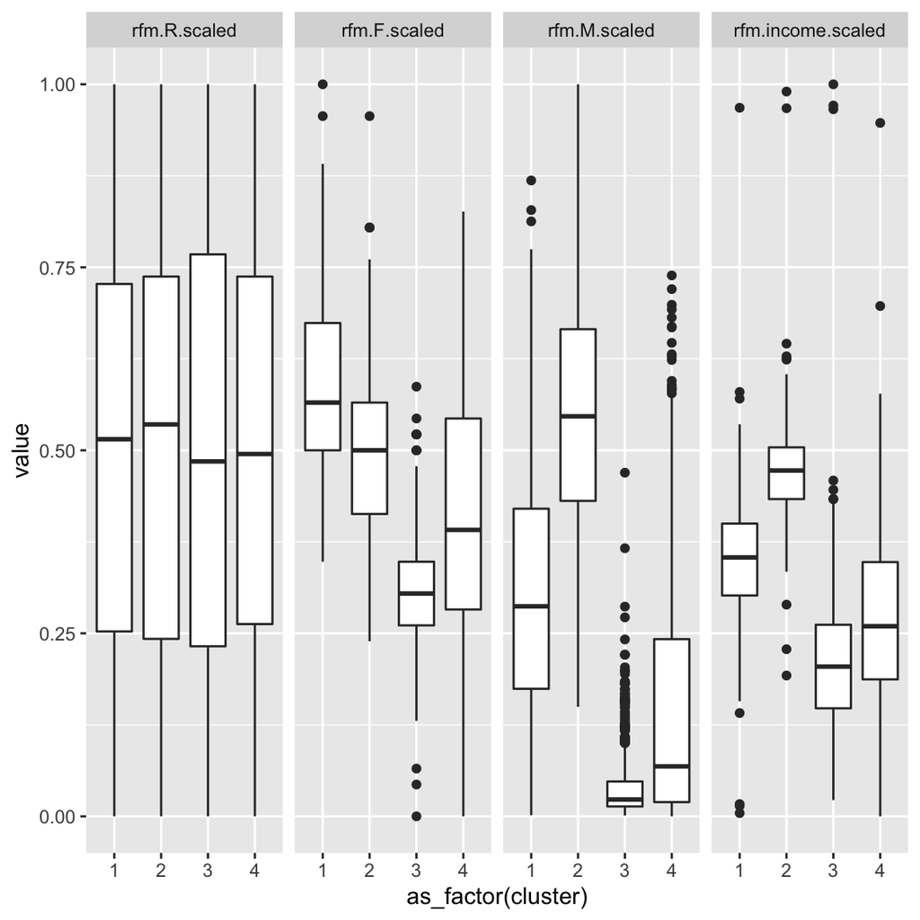

```r
rfm.R = data.clean$Recency
rfm.F = rowSums(data.clean[,16:20])
rfm.M = rowSums(data.clean[,10:15])
rfm.income = data.clean$Income
RFM = data.frame(rfm.R,rfm.F,rfm.M,rfm.income)

RFM$rfm.R.scaled = min.max.scale(RFM$rfm.R)
RFM$rfm.F.scaled = min.max.scale(RFM$rfm.F)
RFM$rfm.M.scaled = min.max.scale(RFM$rfm.M)
RFM$rfm.income.scaled = min.max.scale(RFM$rfm.income)

RFM$cluster = kmean.model.4.cluster


# Label the cluster
# plot the rfm in different clusters
RFM%>%
  select(cluster, rfm.R.scaled, rfm.F.scaled, rfm.M.scaled,rfm.income.scaled)%>%
  melt(id='cluster')%>%
  ggplot(aes(as_factor(cluster), value))+
  geom_boxplot()+
  facet_wrap(~variable, ncol = 4)
```